# Assignment2

2023-02-12

## Question 1

We need to generate samples from the requested distributions. We can do so with the following code:

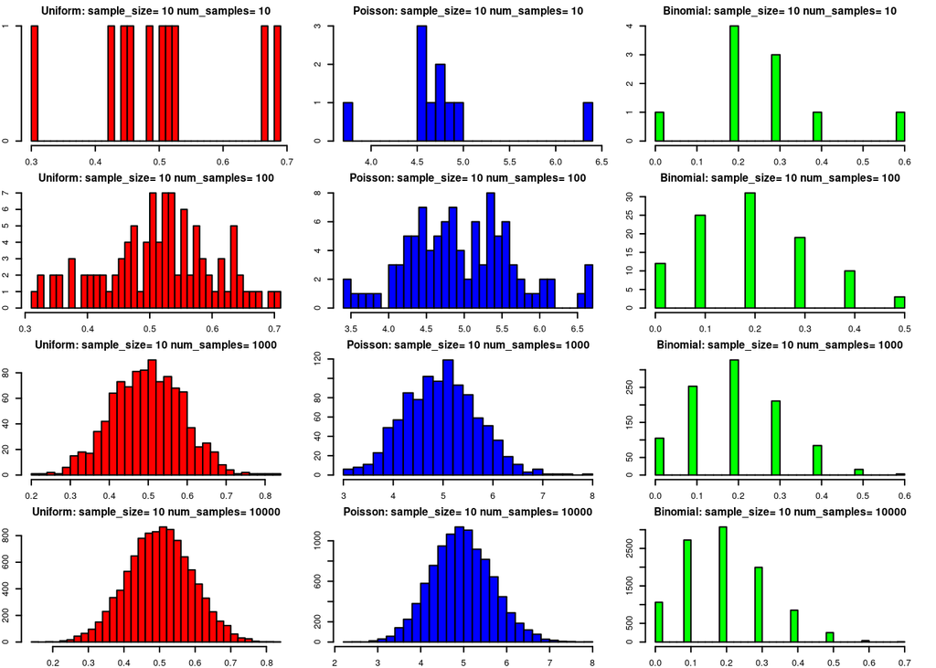

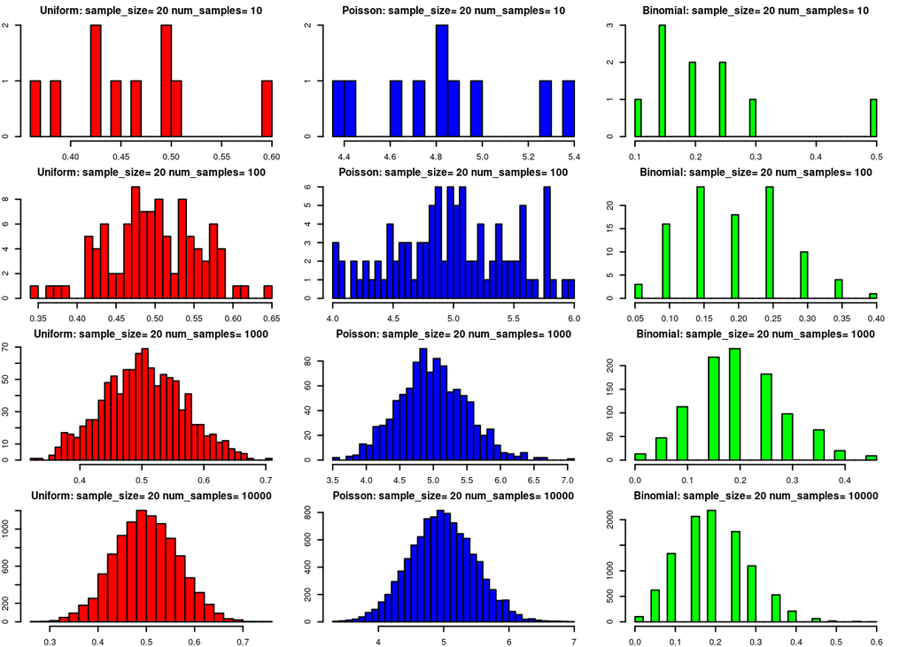

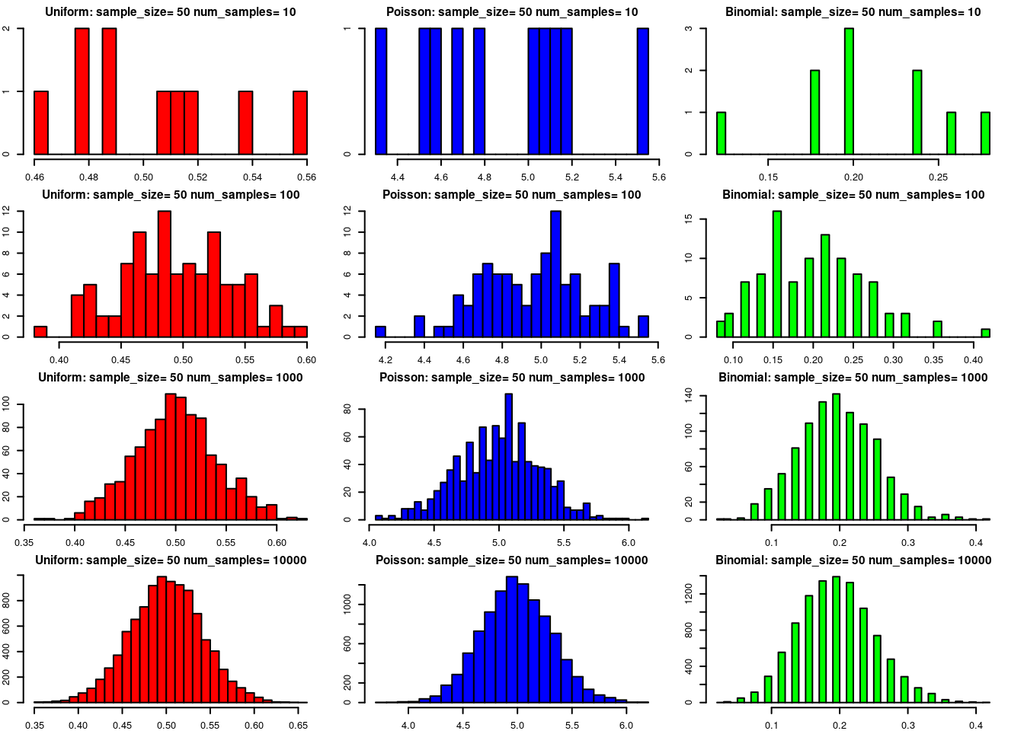

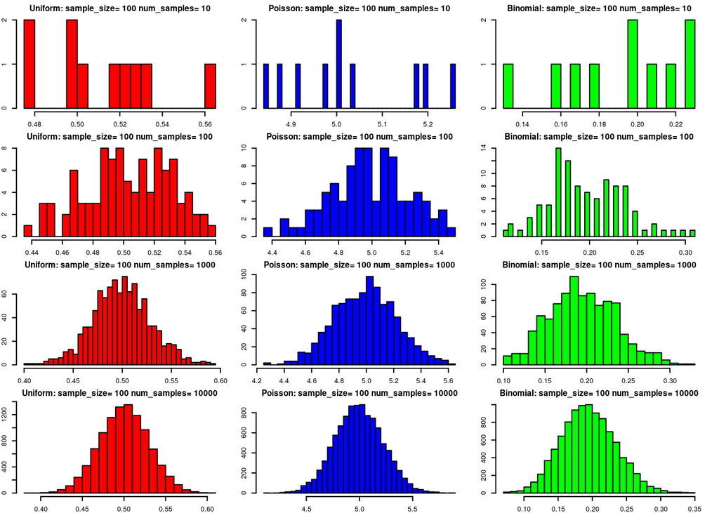

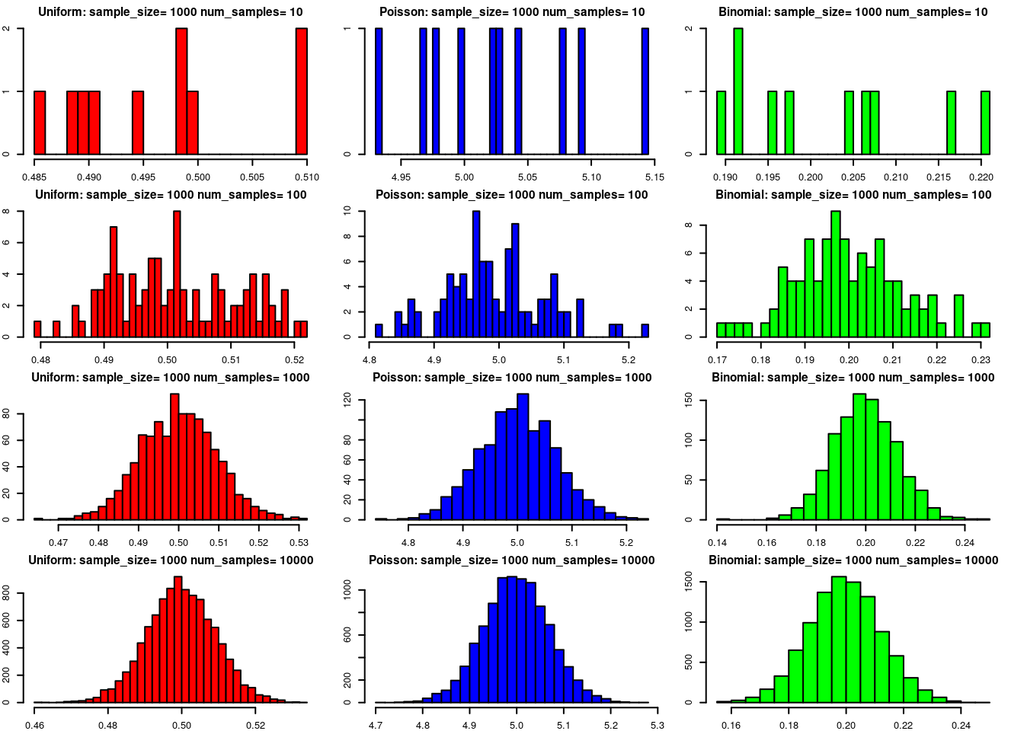

```r
# Specify the sample sizes and number of samples
sample_sizes <- c(10, 20, 50, 100, 1000)
num_samples <- c(10, 100, 1000, 10000)

# Create list objects to store the samples
samples_uniform <- list()
samples_poisson <- list()
samples_binomial <- list()

# Generate the samples using a for loop
for (i in seq_along(sample_sizes)) {
  m <- sample_sizes[i]
  samples_uniform[[i]] <- list()
  samples_poisson[[i]] <- list()
  samples_binomial[[i]] <- list()
  for (j in seq_along(num_samples)) {
    n <- num_samples[j]
    samples_uniform[[i]][[j]] <- replicate(m, runif(n, 0, 1))
    samples_poisson[[i]][[j]] <- replicate(m, rpois(n, 5))
    samples_binomial[[i]][[j]] <- replicate(m, rbinom(n, 1, 0.2))
  }
}

# Calculate the sample means
mean_samples_uniform <- lapply(samples_uniform, function(x) {
  lapply(x, rowMeans)
})

mean_samples_poisson <- lapply(samples_poisson, function(x) {
  lapply(x, rowMeans)
})

mean_samples_binomial <- lapply(samples_binomial, function(x) {
  lapply(x, rowMeans)
})

# Plot the histograms of the sample means
par(mfrow=c(4,3), cex=0.4, mar = rep(2, 4))
for (i in seq_along(sample_sizes)) {
  for (j in seq_along(num_samples)) {
    hist(mean_samples_uniform[[i]][[j]], main=paste("Uniform: sample_size=", sample_sizes[i], "num_samples=", num_samples[j]),
         xlab="Sample Mean", col="red", breaks=30)
    hist(mean_samples_poisson[[i]][[j]], main=paste("Poisson: sample_size=", sample_sizes[i], "num_samples=", num_samples[j]),
         xlab="Sample Mean", col="blue", breaks=30)
    hist(mean_samples_binomial[[i]][[j]], main=paste("Binomial: sample_size=", sample_sizes[i], "num_samples=", num_samples[j]),
         xlab="Sample Mean", col="green", breaks=30)
  }
}
```

The CLT states that, for iid samples, the standardized sample mean tends towards the standard normal distribution even if the random variables being sampled are not normally distributed. First we can see the effect of fixing the sample size and increasing the number of samples. This leads to the familiar “bell” shape of the standard normal (I added an even higher value for num_samples at the end to make this even more explicit). If we fix the number of samples and increase the sample size, we can observe that the variance decreases (i.e the x axis becomes a smaller band of values).

The outcome is the same for all three distributions, this is because the CLT and law of large numbers applies to any sequence of iid random variables*.

*if the variance of the RVs are finite, which it is for all of these.

## Question 2

First, read in the data

```r
# Read the txt file into a data frame
salt <- read.table("salt.txt", header = TRUE, sep = "\t")

# View the data frame
head(salt)
```

```
##    salt
## 1 13.53
## 2 28.42
## 3 48.11
## 4 48.64
## 5 51.40
## 6 59.91
```

Now let’s visualize the data

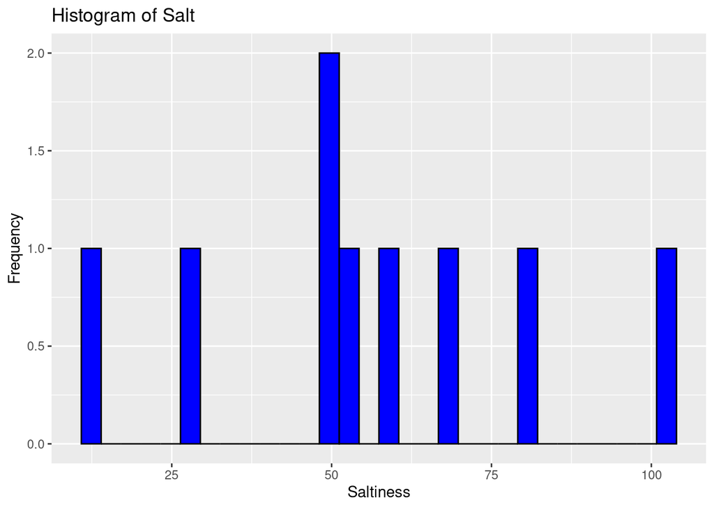

```r
# Load the ggplot2 library
library(ggplot2)

# Create a histogram of the salt variable
ggplot(salt, aes(x = salt)) +
  geom_histogram(fill = "blue", color = "black") +
  labs(x = "Saltiness", y = "Frequency", title = "Histogram of Salt")
```

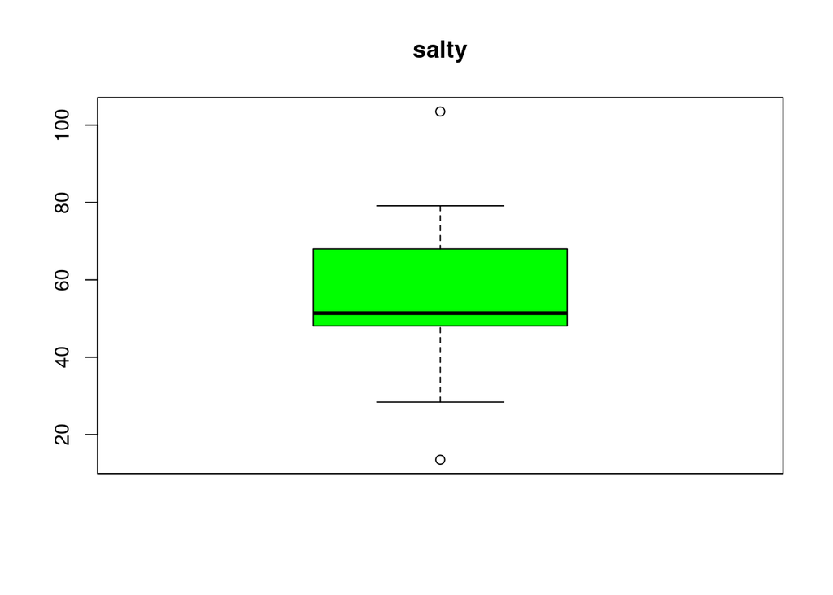

```r
stereogram<-read.table(file ='salt.txt', sep="",header=TRUE)
salty<-stereogram$salt
boxplot(salt,col='green',names=c('salty'))
title('salty')
```

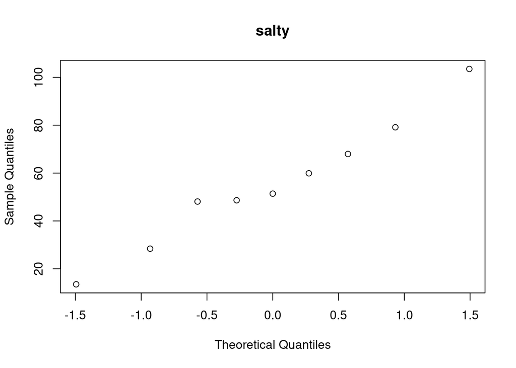

```r
qqnorm(salty,main='salty')
```

Next we can find the skew and kurtosis:

```r
# Load the moments package
library(moments)

# Estimate the skewness of the salt variable
skewness(salt$salt)
```

```
## [1] 0.2056856
```

```r
# Estimate the kurtosis of the salt variable
kurtosis(salt$salt)
```

```
## [1] 2.614503
```

And now, using a bootstrap to estimate a 95% confidence interval for the skew:

```r
# Load the moments and boot packages
library(moments)
library(boot)

# Define a function to compute skewness
boot_skew <- function(x, i) {
  return(skewness(x[i]))
}

# Define a function to compute kurtosis
boot_kurt <- function(x, i) {
  return(kurtosis(x[i]))
}

# Set the number of bootstrap replicates
B <- 1000

# Generate bootstrap samples and compute skewness
skewboot_results <- boot(salt$salt, boot_skew, R = B)
kurtboot_results <- boot(salt$salt, boot_kurt, R = B)
# View the bootstrap results
skewboot_results
```

```
##
## ORDINARY NONPARAMETRIC BOOTSTRAP
##
##
## Call:
## boot(data = salt$salt, statistic = boot_skew, R = B)
##
##
## Bootstrap Statistics :
##      original      bias    std. error
## t1* 0.2056856 -0.09937347   0.6264471
```

```r
kurtboot_results
```

```
##
## ORDINARY NONPARAMETRIC BOOTSTRAP
##
##
## Call:
## boot(data = salt$salt, statistic = boot_kurt, R = B)
##
##
## Bootstrap Statistics :
##     original      bias    std. error
## t1* 2.614503 -0.09080168   0.8129746
```

```r
# Calculate the bootstrap confidence interval
skewboot_ci <- quantile(skewboot_results$t, c(0.025, 0.975))

# Print the bootstrap estimate and confidence interval
cat("Bootstrap skewness estimate: ", mean(skewboot_results$t), "\n")
```

```
## Bootstrap skewness estimate:  0.1063122
```

```r
cat("Bootstrap 95% confidence interval: [", skewboot_ci[1], ", ", skewboot_ci[2], "]\n")
```

```
## Bootstrap 95% confidence interval: [ -1.182257 ,  1.294245 ]
```

```r
# Calculate the bootstrap confidence interval
kurtboot_ci <- quantile(kurtboot_results$t, c(0.025, 0.975))

# Print the bootstrap estimate and confidence interval
cat("Bootstrap kurtosis estimate: ", mean(kurtboot_results$t), "\n")
```

```
## Bootstrap kurtosis estimate:  2.523701
```

```r
cat("Bootstrap 95% confidence interval: [", kurtboot_ci[1], ", ", kurtboot_ci[2], "]\n")
```

```
## Bootstrap 95% confidence interval: [ 1.410823 ,  4.538735 ]
```

Judging from the visualizations and values, it seems like the distribution has slightly positive skew and slightly negative kurtosis, as the value for skew > 0 and the value for kurtosis < 3. But the confidence intervals for both are quite large, and the data size is small.

## Question 3

```r
# Read the txt file into a data frame
fec <- read.table("fecundity.txt", header = TRUE)

# View the data frame
head(fec)
```

```
##     RS   NS
## 1 12.8 35.4
## 2 21.6 27.4
## 3 14.8 19.3
## 4 23.1 41.8
## 5 34.6 20.3
## 6 19.7 37.6
```

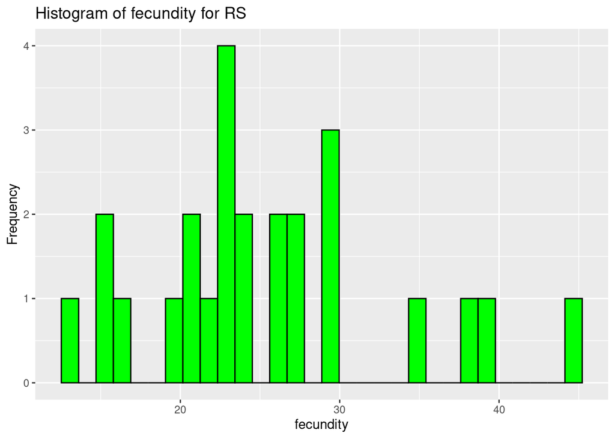

```r
# Create a histogram of the salt variable
ggplot(fec, aes(x = fec$RS)) +
  geom_histogram(fill = "green", color = "black") +
  labs(x = "fecundity", y = "Frequency", title = "Histogram of fecundity for RS")
```

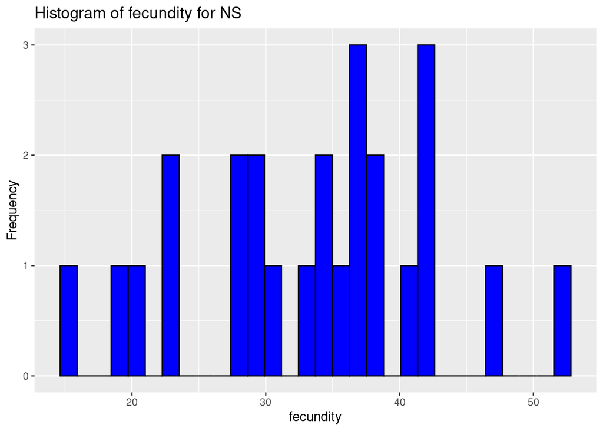

```r
# Create a histogram of the salt variable
ggplot(fec, aes(x = fec$NS)) +
  geom_histogram(fill = "blue", color = "black") +
  labs(x = "fecundity", y = "Frequency", title = "Histogram of fecundity for NS")
```

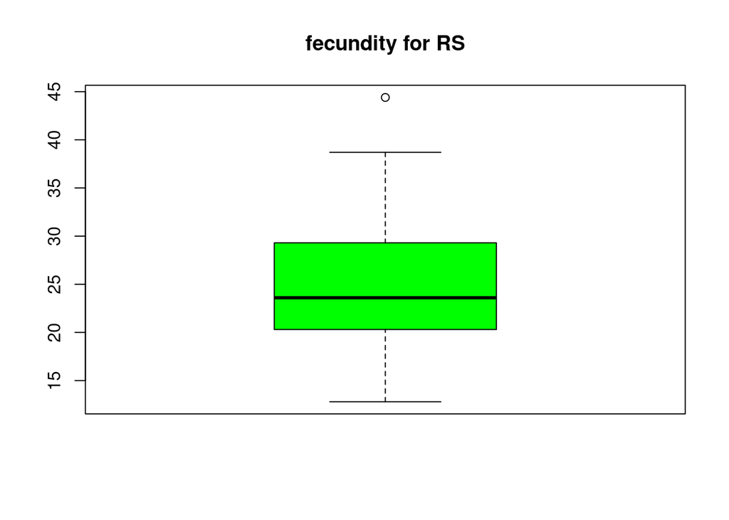

```r
boxplot(fec$RS,col='green',names=c('fecundity'))
title('fecundity for RS')
```

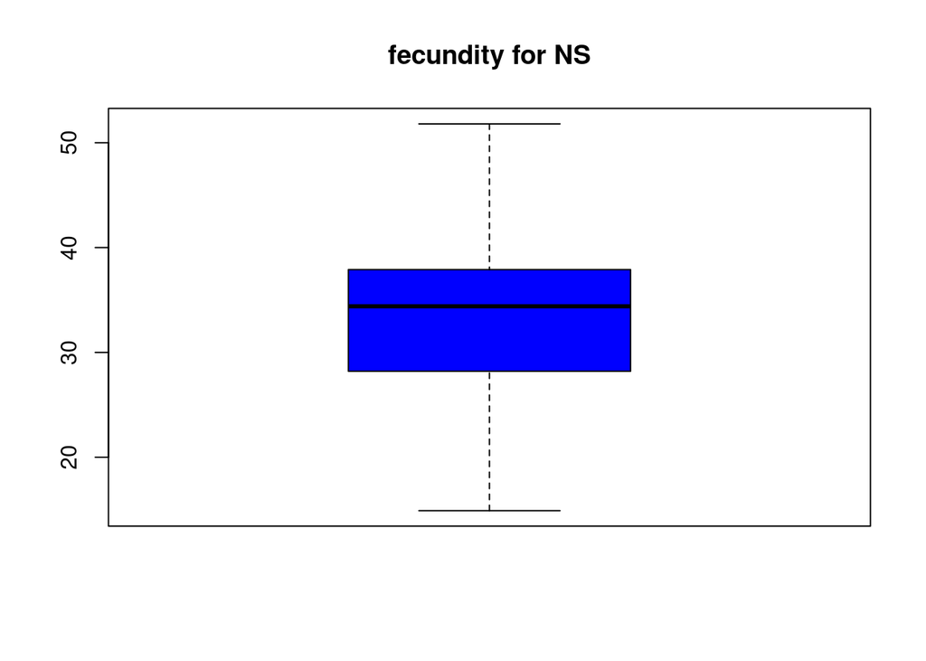

```r
boxplot(fec$NS,col='blue',names=c('fecundity'))
title('fecundity for NS')
```

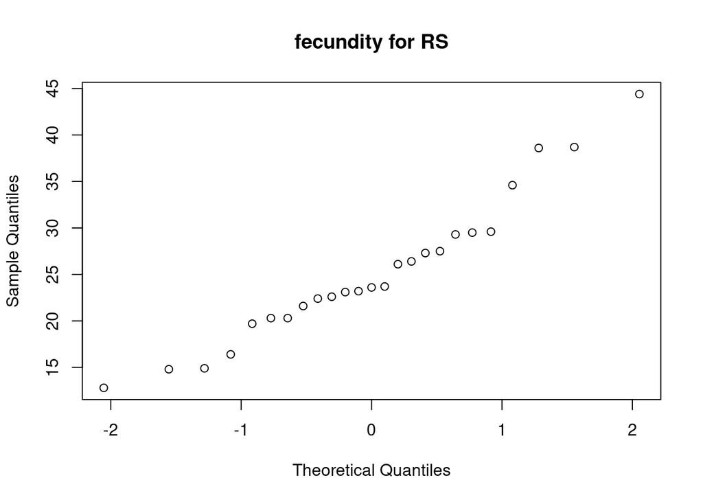

```r
qqnorm(fec$RS,main='fecundity for RS')
```

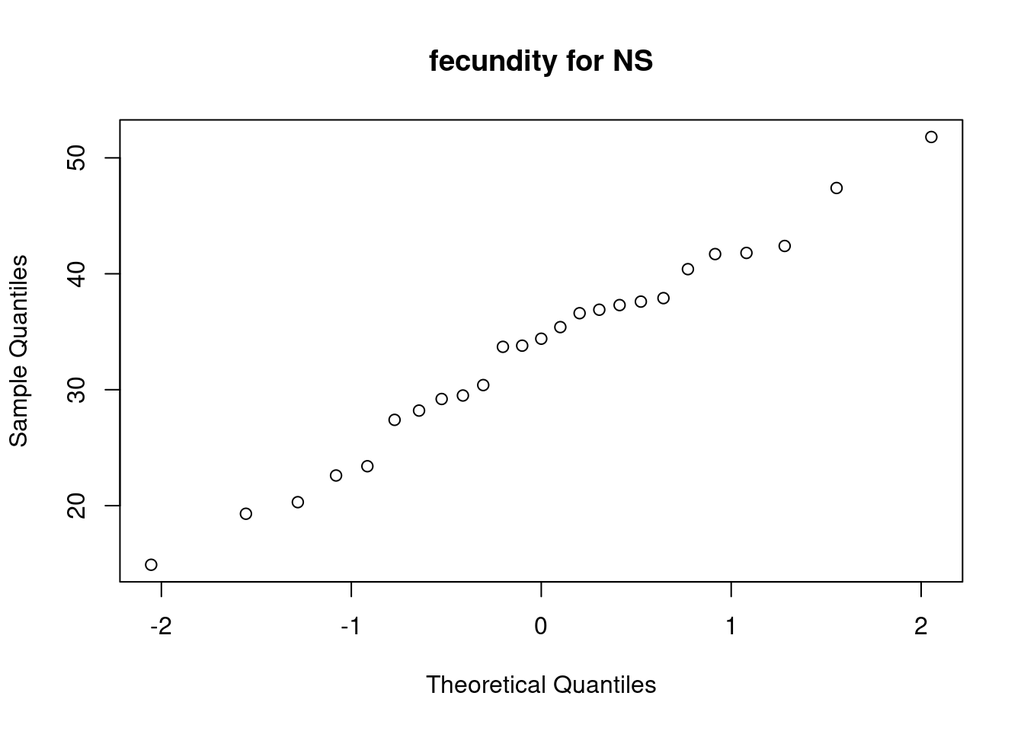

```r
qqnorm(fec$NS,main='fecundity for NS')
```

```r
ttest <- t.test(x=fec$RS, y= fec$NS)
ttest
```

```
##
##  Welch Two Sample t-test
##
## data:  fec$RS and fec$NS
## t = -3.4251, df = 47.087, p-value = 0.001283
## alternative hypothesis: true difference in means is not equal to 0
## 95 percent confidence interval:
##  -12.882696  -3.349304
## sample estimates:
## mean of x mean of y
##    25.256    33.372
```

```r
vartest <- var.test(x = fec$NS,  y=fec$RS)
vartest
```

```
##
##  F test to compare two variances
##
## data:  fec$NS and fec$RS
## F = 1.3236, num df = 24, denom df = 24, p-value = 0.4974
## alternative hypothesis: true ratio of variances is not equal to 1
## 95 percent confidence interval:
##  0.5832755 3.0036468
## sample estimates:
## ratio of variances
##           1.323614
```

## Question 4

```r
# read in the text file
# 1. Read the text file
lines <- readLines("fabric.txt")

# 2. Split each row into separate elements
data_list <- strsplit(lines, " ")

# 3. Convert character elements to numeric
data_list <- lapply(data_list, as.numeric)
#
data_list
```

```
## [[1]]
##  [1]  NA 1.2 0.9 0.7 1.0 1.7 1.7 1.1 0.9 1.7 1.9 1.3 2.1 1.6 1.8 1.4 1.3 1.9 1.6
## [20] 0.8 2.0 1.7 1.6 2.3 2.0
##
## [[2]]
## numeric(0)
##
## [[3]]
## [1]  NA 1.6 1.5 1.1 2.1 1.5 1.3 1.0 2.6
```

```r
hvals <- as.vector(t(data_list[[1]][-1]))

pvals <- as.vector(t(data_list[[3]][-1]))

hvals
```

```
##  [1] 1.2 0.9 0.7 1.0 1.7 1.7 1.1 0.9 1.7 1.9 1.3 2.1 1.6 1.8 1.4 1.3 1.9 1.6 0.8
## [20] 2.0 1.7 1.6 2.3 2.0
```

```r
pvals
```

```
## [1] 1.6 1.5 1.1 2.1 1.5 1.3 1.0 2.6
```

```r
fab_data <- data.frame(col1=hvals, col2=pvals)
colnames(fab_data) <- c("H", "P")
head(fab_data)
```

```
##     H   P
## 1 1.2 1.6
## 2 0.9 1.5
## 3 0.7 1.1
## 4 1.0 2.1
## 5 1.7 1.5
## 6 1.7 1.3
```

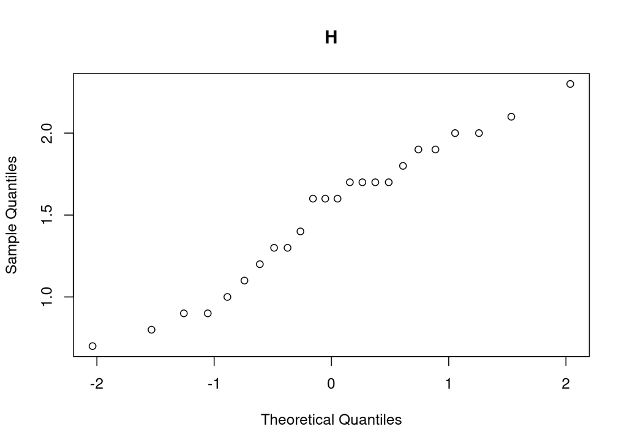

```r
qqnorm(fab_data$H,main='H')
```

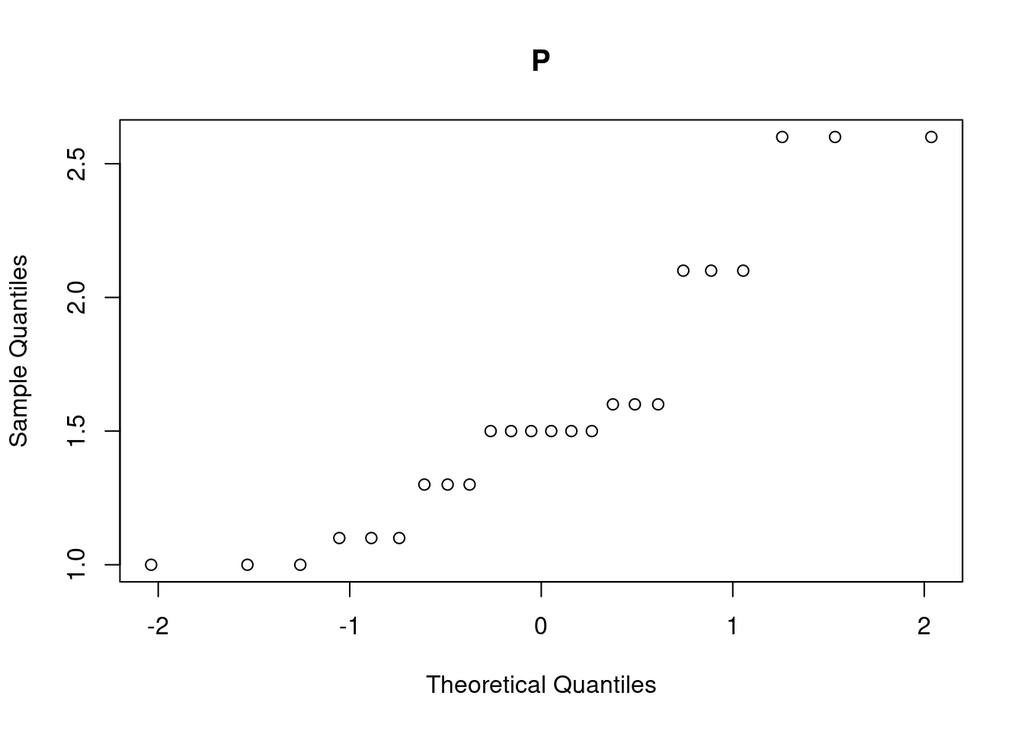

```r
qqnorm(fab_data$P,main='P')
```

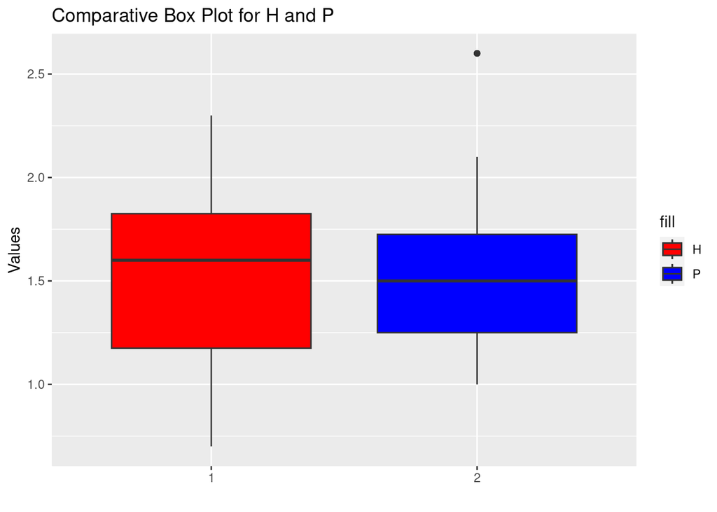

```r
# Create the box plot
my_plot <- ggplot(fab_data, aes(x = factor(1), y = H, fill = "H")) +
  geom_boxplot() +
  geom_boxplot(aes(x = factor(2), y = P, fill = "P")) +
  scale_fill_manual(values = c("H" = "red", "P" = "blue")) +
  xlab("") +
  ylab("Values") +
  ggtitle("Comparative Box Plot for H and P")

# Print the plot
print(my_plot)
```

```r
mean(fab_data$H)
```

```
## [1] 1.508333
```

```r
mean(fab_data$P)
```

```
## [1] 1.5875
```